# git pull upstream master

# Answer questions from the previous session

# Programmation

- How is working/what is a computer ?
- What is a program ?
- Animation with 3 people:
  - One central memory
  - One program memory
  - One arithmetic logic unit
- First program:

  ```
   *0 = 1
   *1 = 2
  ```

- Second program:

  ```
  1:      *1 = 0
  2:      *2 = 0
  3:      *0 = *1 >= 4
  4:      if *0 goto 8
  5:      *2 = *2 + *1
  6:      *1 = *1 +1
  7:      goto 3
  8:      END
  ```

### Assembly language

An assembly language:

- low-level programming language
- strong (generally one-to-one) correspondence between the language and the computer *code instructions*.

[wikipedia: assembly language](http://en.wikipedia.org/wiki/Assembly_language)

### High level language

- strong abstraction from the details of the computer

[wikipedia: High level programming language](http://en.wikipedia.org/wiki/High-level_programming_language)

Examples of Compiled language:

- Fortran
- C
- C++
- Java

Examples of interpreted language:

- python
- perl
- matlab

# Compilation and linking C++

## Compiler

- A computer program transforming source code (in the source language) into another computer language (the target language)

[wikipedia: compiler](http://en.wikipedia.org/wiki/Compiler)

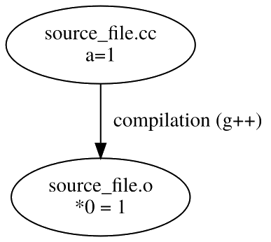

## GNU C++ compiler: g++

```
g++ -Wall -c source_file.cc
```

- This will produce a file object *source_file.o*
- "-Wall" to output all warnings and errors
- Multiple files with multiple symbols.

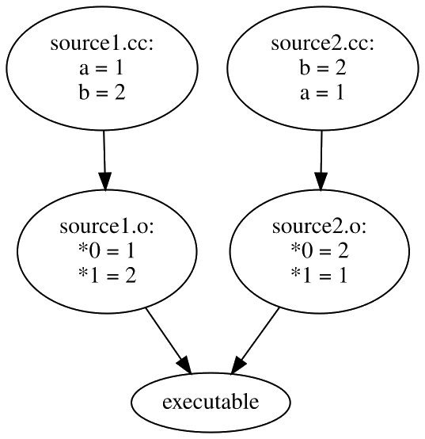

Question: What are the addresses when files are separated ?

## Linker or Link editor (wikipedia: linker)

- takes one or more object files (generated by a compiler)
- combines them into a single executable program.

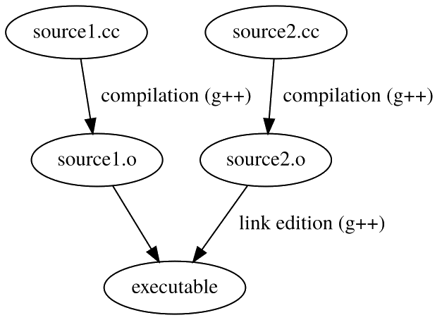

```
g++  object1.o object2.o object3.o -o exec
```

# A first C++ program

## Open the file 'hello.cpp'

```
#include <iostream>
int main(int argc, char *argv[]) {

  /* This is a comment */

  // Print "Hello World" to the screen
  std::cout << "Hello World\n";
  return 0;
}
```

```
#include <iostream>
int main(int argc, char *argv[]) {

  /* This is a comment */

  // Print "Hello World" to the screen
  std::cout << "Hello World\n";
  return 0;
}
```

```
#include <iostream>
int main(int argc, char *argv[]) {

  /* This is a comment */

  // Print "Hello World" to the screen
  std::cout << "Hello World\n";
  return 0;
}
```

```
#include <iostream>
int main(int argc, char *argv[]) {

  /* This is a comment */


  // Print "Hello World" to the screen
  std::cout << "Hello World\n";
  return 0;
}
```

```
#include <iostream>
int main(int argc, char *argv[]) {

  /* This is a comment */

  // Print "Hello World" to the screen
  std::cout << "Hello World\n";
  return 0;
}
```

```
#include <iostream>
int main(int argc, char *argv[]) {

  /* This is a comment */

  // Print "Hello World" to the screen
  std::cout << "Hello World\n";
  return 0;
}
```

```
#include <iostream>
int main(int argc, char *argv[]) {

  /* This is a comment */

  // Print "Hello World" to the screen
  std::cout << "Hello World\n";
  return 0;
}
```

## Let's compile the code

```
g++ -Wall hello.cpp -o hello
```

## Let's launch it

```
./hello
```

# Build systems and Makefiles

- **Make**: utility to automatically build executable programs and libraries
- target program rules specified in file **makefile**

[wikipedia: Makefiles](http://en.wikipedia.org/wiki/Make_software)

## Rules syntax

```
target: dependency1 dependency2 dependency3
<TAB> rule
```

- A simple example for building several files into an executable

```
all: file1.o file1.hh main.o
    gcc -o exec file1.o main.o

file1.o: file1.hh
    g++ -c file1.cc

main.o: file1.hh
    g++ -c main.cc
```

- Using intermediate variables

```
CXX=g++
LD=gcc
CXXFLAGS=-g -Wall
LDFLAGS=-g -Wall

all: file1.o file1.hh main.o
    $(LD) $(LDFLAGS) -o exec file1.o main.o

file1.o: file1.hh
    $(CXX) $(CXXFLAGS) -c file1.cc

main.o: file1.hh
    $(CXX) $(CXXFLAGS) -c main.cc
```

## CMake

### What is CMake ?

- CMake is cross-platform free and open-source software for managing the build process of software using a compiler-independent method.
- It is designed to support directory hierarchies and applications that depend on multiple libraries.
- It is used in conjunction with native build environments such as make, Apple's Xcode, and Microsoft Visual Studio.
- It has minimal dependencies, requiring only a C++ compiler on its own build system.
- Concretely, it is a build-system generator, which is multi-plateform.

### CMake basic syntax

```
cmake_minimum_required (VERSION 2.6)
project (GeneratedFromCodeGenerator)

add_executable(main
main.cc
)
```

The first lines provide indication about the project and CMake version requirements.

The command **add_executable** specifies that there is an executable to add, named **main**, and the files to include are listed below: **main.cc**.

### Link to another library (example math library libm.so)

```
cmake_minimum_required (VERSION 2.6)
project (GeneratedFromCodeGenerator)

add_executable(main
main.cc
)

target_link_libraries(main m)
```

### The advantages of cmake

- You can have two build directory, one configured in Debug, one in Release. Building the Debug/Release can be made simply by changing directory.
- CMake has many generators
- Borland Makefiles
- MSYS Makefiles
- MinGW Makefiles
- NMake Makefiles
- NMake Makefiles JOM
- Ninja
- Unix Makefiles
- Watcom WMake
- Visual Studio 6
- Visual Studio 7
- Visual Studio 7 .NET 2003
- Visual Studio 8 2005
- Visual Studio 9 2008
- Visual Studio 10 2010
- Visual Studio 11 2012
- Visual Studio 12 2013
- Xcode
- CodeBlocks
- CodeLite
- Eclipse CDT4
- KDevelop3
- Kate
- Sublime Text 2

# CMake default generator

In general, Makefiles have to be generated with CMake. For this, the procedure is:

```
mkdir build
cd build
ccmake ../
```

Then the GUI should launch. Hit 'c' to configure. Hit 'g' to generate.

## *CMAKE_BUILD_TYPE* (debug or not)

- Debug (with debug symbols)
- Release (optimized)

# CLion reads **automatically** CMakeLists (recommended)

# C/C++ basic syntax

- comments:

```
// my single line comment

/* here is
   my multiline comment
*/
```

- generic instruction syntax: Ends with ;

```
instruction;
```

- blocks (scope concept)

```
{
SOMECODE;
}
```

[wikipedia: scope](http://en.wikibooks.org/wiki/C%2B%2B_Programming/Programming_Languages/C%2B%2B/Code/Statements/Variables#Locality_.28hardware.29)

### Variables

```
// definition of some variables
type var_name;
```

Possible (basic) types: char, short, int, long int, float, double, long double, bool

- naming convention: name must make sense
- const, signed, unsigned

[wikipedia: types](http://en.wikibooks.org/wiki/C%2B%2B_Programming/Programming_Languages/C%2B%2B/Code/Statements/Variables#Endianness)

```
int a = 2;
double t = 34e10;
```

### Type conversion (needs to be explicitly converted)

```
#include <cstdlib>

int a = atoi("2");
double b = atof("2.3");
```

### Variable scope

- A variable defined outside of any scope is **global**.
- Otherwise its name makes sense **only** in the block they are defined.

```
{
  int a = 1;
  { int a = 2; }
  // here a is still 1
}
```

### Operators

- Algebra: + - * / = ()

```
int a = 2;
int b = 1;
int d = 3;
int e = (a + b) / d;
e += 1;
e++;
e--;
int f = e++;
int g = ++f;
```

### Arrays

```
int a[2];
a[0] = 1;
a[1] = 2;
```

### Pointers

- A pointer is a specific variable type to store the address of a variable:

```
int a;
int *ptr = &a;
```

- You can access the contained value using the * operator

```
*ptr = 1;
```

- Pointers are incrementable:

```
int a[2];
int *ptr = a;
*ptr = 0; // a[0] = 0;
ptr++;
*ptr = 1; // a[1] = 1;
```

### References

- Constant pointers, aliases

```
int a[2];
int &ref = a[0];
ref = 0; // a[0] = 0;
```

[wikipedia: Pointers](http://en.wikibooks.org/wiki/C%2B%2B_Programming/Operators/Pointers)

### **if** statement: decisional branching

```
int a = 1;
bool c;

if (a == 2) {
  c = true;
} else {
  c = false;
}
```

[wikipedia: if then else](http://en.wikibooks.org/wiki/C%2B%2B_Programming/Programming_Languages/C%2B%2B/Code/Statements/Flow_Control#if_.28Fork_branching.29)

### **switch & case**: decisional branching with cases

```
int a;
int res;
switch (a) {
case 1:
  res = 1;
  break;
case 2:
  res = 2;
case 3:
  res = 3;
  break;
default:
  res = -1;
}
```

beware the **break** keyword to finish a case !

[wikipedia: switch case](http://en.wikibooks.org/wiki/C%2B%2B_Programming/Programming_Languages/C%2B%2B/Code/Statements/Flow_Control#switch_.28Multiple_branching.29)

### **while** loops

```
while (condition) {
  instructions;
}
```

[wikipedia: while loops](http://en.wikibooks.org/wiki/C%2B%2B_Programming/Programming_Languages/C%2B%2B/Code/Statements/Flow_Control#while_.28Preconditional_loop.29)

### **for** loops:

```
for (init; test_condition; increment_instruction) {
  instructions;
}
```

```
int res = 0;
for (int a = 0; a < 10; ++a) {
  res += a;
}
```

[wikipedia: For loops](http://en.wikibooks.org/wiki/C%2B%2B_Programming/Programming_Languages/C%2B%2B/Code/Statements/Flow_Control#for_.28Preconditional_and_counter-controlled_loop.29)

### Functions

```
return_type function_name(type1 param1, type2 param2, ...) {
  instructions;
  return res;
}
```

[wikipedia: functions](http://en.wikibooks.org/wiki/C%2B%2B_Programming/Code/Statements/Functions)

### Main function: entry point of any program.

```
int main(int argc, char ** argv){
   ...
}
```

When you call your program like

```
> ./hello tata 12 67
```

argc is 4, and argv is a pointer of string (char array) containing "hello" "tata" "12" and "67"

[wikipedia: main function](http://en.wikibooks.org/wiki/C%2B%2B_Programming/Code/Statements/Functions#main)

What is the memory structure of argv ?

### Preprocessing macro

- Operation performed before compilation
- Text replacement & macro-function
- Include other files

```
#include "some_other_file.hh"
#include <standard_header.hh>
```

- define/undef

```
#define AVOGADRO 6.02214129e23
instructions;

#undef AVOGADRO
```

[wikipedia: preprocessing macro](https://en.wikibooks.org/wiki/C%2B%2B_Programming/Programming_Languages/C%2B%2B/Code/Compiler/Preprocessor#Macros)

### Simple output to screen

```
#include <iostream>

int main() {
  int a = 1e6;
  std::cout << "wanna have fun a " << a << " times" << std::endl;
}
```

```
#include <iostream>

int main() {
  int a = 1e6;
  std::cout << "wanna have fun a " << a << " times" << std::endl;
}
```

```
#include <iostream>

int main() {
  int a = 1e6;
  std::cout << "wanna have fun a " << a << " times" << std::endl;
}
```

# Interactive session on (C++)

- Source files (.cc .cxx .cpp .hh .hpp convention)
- CMake
- Exercise to split a source file into header and implementation
- Manipulating the argc and argv
- Loops
- Debugger GDB
- Implementing the computation of pi in C++

# Numbers

## Integer numbers

Integers are numbers stored with a fixed number of bits

- char or unsigned char: 8bits (1 Byte) $[-128,127]$ or $[0,255]$
- short or unsigned short: 16bits (2 Bytes) $[-2^{15},2^{15}-1]$ or $[0,2^{16}-1 = 65535]$
- integer or unsigned int: 32bits (4 Bytes) $[-2^{31},2^{31}-1]$ or $[0,2^{32}-1 = 4294967295]$

## Floating point numbers

Any floating point number in a computer are stored with the representation: $$(-1)^s \times c \times b^q$$

- $(-1)^s$ is the sign ($s$ is its encoding)
- $c$ is the significand, an integer
- $b$ is the base
- $q$ is an (integer) exponent

### Standards ([wikipedia: IEEE floating point standard](http://en.wikipedia.org/wiki/IEEE_floating_point))

- **float** (single) precision (4 Bytes = 32 bits), significand 24 bits ~ 7.22 decimal digits.
- **double** precision (8 Bytes = 64 bits), significand 53 bits ~ 15.95 decimal digits.
- **long double** (16 Bytes = 128 bits), significand 113 bits ~ 34.02 decimal digits.

[wikipedia: floating point in modern computers](http://en.wikipedia.org/wiki/Floating-point#IEEE_754:_floating_point_in_modern_computers)

- Special values
  - $\pm$ 0
  - $\pm$ inf
  - NaN (not a number)
- Rounding problems (for demo assume 4 digits available)
  - $1. + 10^{-4} = 1.$

## Interactive session Manipulating floating point numbers

- Casting from integer to float/double
- Overflow
- Underflow